# 2-DE_Analysis

Katia Otterstedt

2023-09-06

# Introduction

We have successfully acquired the expression and survival data as outlined in the “1-Preprocessing_DE” script. The next step entails the stratification of our patient cohort into two distinct groups, predicated on a defined cutpoint within the RAC1 gene expression profile.

## Libraries

This analysis requires several libraries, including ‘survminer’ for cutpoint determination based on survival prognosis, ‘edgeR’ for conducting Differential Expression (DE) analysis, as well as ‘EnhancedVolcano,’ ‘RColorBrewer,’ and ‘ggrepel’ for the creation of aesthetically pleasing visual representations.

```r
library(survminer)
library(edgeR)
library(EnhancedVolcano)
library(RColorBrewer) # For a colourful plot
library(ggrepel)
```

# Obtaining cutpoint

Employing survival information and expression data which has been normalized in counts per million (cpm) during the previous phase of our analysis, we invoke the ‘surv_cutpoint’ function to discern a precise cutpoint. The purpose of this cutpoint is to categorize patients according to their RAC1 expression levels.

```r
COAD.cut <- surv_cutpoint(
  COAD.surv,
  time = "overall_survival",
  event = "event",
  variables = "RAC1")

# Getting the value of cutpoint in CPM and statistic
summary(COAD.cut)
```

```
##      cutpoint statistic
## RAC1      381  1.391853
```

```r
# Checking some statistics related to out gene of interest
mean(COAD.surv$RAC1, na.rm = TRUE)
```

```
## [1] 402.8559
```

```r
sd(COAD.surv$RAC1, na.rm = TRUE)
```

```
## [1] 110.8708
```

```r
median(COAD.surv$RAC1, na.rm = TRUE)
```

```
## [1] 388
```

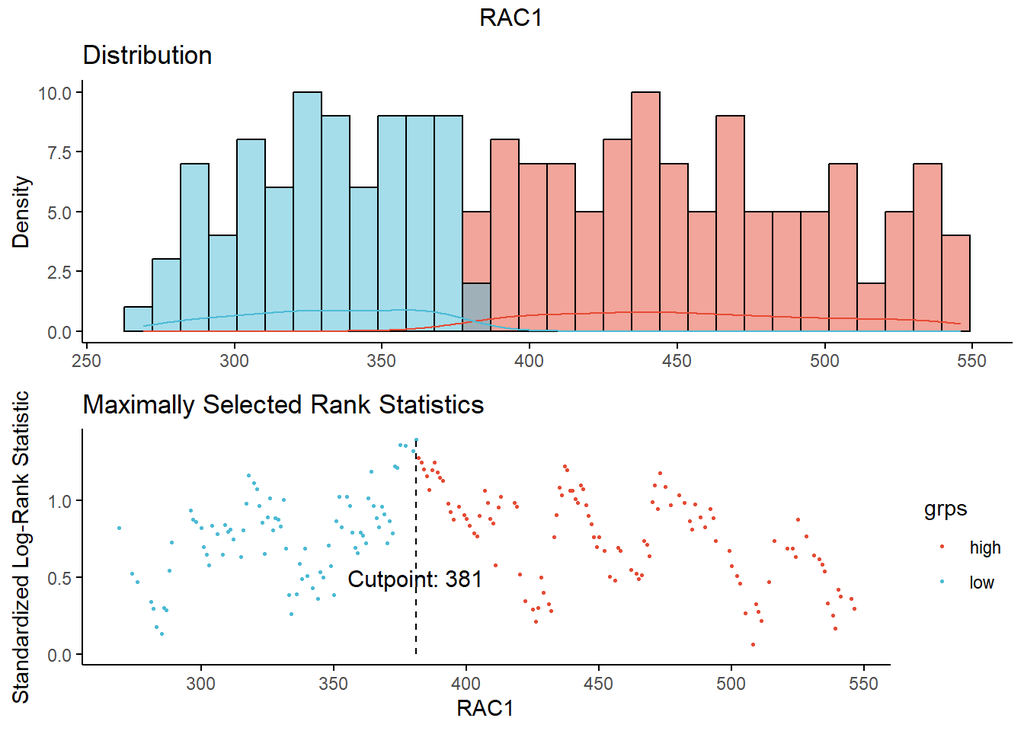

```r
# Plotting the cutpoint
plot(COAD.cut, "RAC1", palette = "npg")
```

```r
# Extracting cutpoint
cutpoint <- COAD.cut[["cutpoint"]]$cutpoint
```

Once the cutpoint has been determined, we proceed to classify patients, generating a vector that encapsulates their unique barcodes alongside their respective categorization in relation to the established cutpoint.

```r
#RAC1 is row 7245
groups <- ifelse(counts_matrix_normalised[7245, ] <= cutpoint, "low", "high")
table(groups)
```

```
## groups
## high  low
##  243  215
```

# Differential expression analysis

## EdgeR

Our initial approach into acquiring Differentially Expressed Genes (DEGs) involves the utilization of EdgeR. EdgeR operates on a negative binomial distribution model for the identification of DEGs.

```r
# We first create a DGEList object
y <- DGEList(counts=counts_matrix, group = groups)
# Setting "low" expression level as control
y$samples$group <- relevel(y$samples$group, ref="low")
# Filter out lowly expressed genes
keep <- filterByExpr(y)
summary(keep)
```

```
##    Mode   FALSE    TRUE
## logical   41333   19327
```

```r
y<- y[keep,,keep.lib.sizes=FALSE]
```

While EdgeR calculates normalization factors for downstream analysis, it retains the original raw counts, refraining from further normalization. For the specific scope of this analysis, the inclusion of a model matrix is not mandatory due to the presence of only two conditions. However, it is prudent to retain code pertaining to matrix generation to ensure script versatility under differing circumstances. Subsequently, the script proceeds with data normalization and dispersion calculation, culminating in the identification of DEGs. These genes are selected based on a false discovery rate (FDR) threshold of less than 0.05 and a log(FoldChange) threshold greater than 1 or 2.

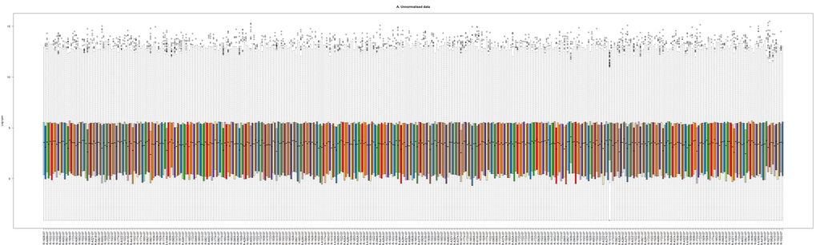

```r
#Plotting data before normalisation
nsamples <- ncol(y) #Number of samples
col <- brewer.pal(nsamples, "Paired")
lcpm <- cpm(y, log=TRUE)
boxplot(lcpm, las=2, col=col, main="")
title(main="A. Unnormalised data",ylab="Log-cpm")
```

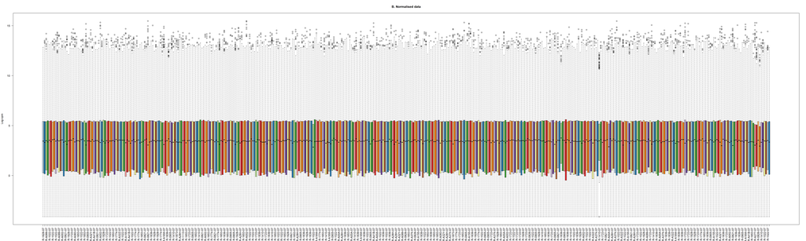

```r
# Performs the trimmed mean of M-values (TMM) normalization calculating normalization factors
y <- calcNormFactors(y, method = "TMM")

# Creating a design matrix
design <- model.matrix(~ 0 + y$samples$group)
colnames(design) <- levels(y$samples$group)

#Plotting data after normalisation
lcpm <- cpm(y, log=TRUE)
boxplot(lcpm, las=2, col=col, main="")
title(main="B. Normalised data",ylab="Log-cpm")
```

```r
# Calculates dispersion using classic mode
y <- estimateDisp(y, design = design, robust = T) # We use robust to treat possible outliers

# Performs an exact test for negative binomial distribution
et <- exactTest(y) # Calculates p-values

# Makes decisions about which genes show significant differences
is.de <- decideTestsDGE(et) # Uses p-values
summary(is.de)
```

```
##        high-low
## Down       5590
## NotSig     9695
## Up         4042
```

```r
# Obtaining a summary of the most significant results in the analysis
# n = Inf => obtaing all results from the analysis
et_tags<-topTags(et, n = Inf)

x<-as.data.frame(et_tags)


# Classifying into upregulated/stable/downregulated using FDR < 0.05
# logFC >= 1
x$Expression = ifelse(x$FDR < 0.05 & abs(x$logFC) >= 1,
                      ifelse(x$logFC> 1 ,'Up','Down'),
                      'Stable')
table(x$Expression)
```

```
##
##   Down Stable     Up
##    172  19134     21
```

```r
# logFC >= 2
x$Expression2 = ifelse(x$FDR < 0.05 & abs(x$logFC) >= 2,
                       ifelse(x$logFC> 2 ,'Up','Down'),
                       'Stable')
table(x$Expression2)
```

```
##
##   Down Stable     Up
##     11  19312      4
```

```r
# Obtaining names of up and down genes
genes_up <- row.names(x[(x$Expression == "Up")&(x$PValue<0.05), ])
genes_down<- row.names(x[(x$Expression == "Down")&(x$PValue<0.05), ])
```

### Visual representation

To facilitate the understanding of our findings, we decided to presentat results in the form of a volcano plot. This graphical representation effectively showcases both upregulated and downregulated genes, accompanied by their corresponding fold changes and associated p-values.

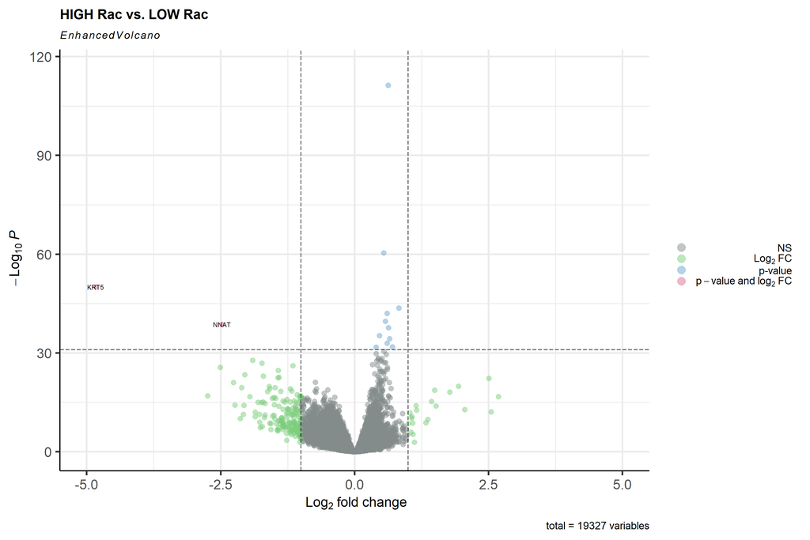

```r
EnhancedVolcano(x,
                lab = rownames(x),
                x= "logFC",
                y= "PValue",
                title = "HIGH Rac vs. LOW Rac",
                pCutoff = 10e-32,
                FCcutoff = 1,
                pointSize = 3.0,
                labSize = 3.0,
                xlim = c(-5,5),
                # boxedLabels = TRUE,
                col = c("azure4", "palegreen3", "skyblue3", "palevioletred"),
                colAlpha = 0.5,
                legendPosition = 'right')
```

## LimmaVoom

The Limma package also performs differential expression analysis, but it is based on a linear model rather than a negative binomial distribution. It shares a big proportion of the pipeline with EdgeR, up until the calculation of normalisation factors. After that, they diverge and Limma pipeline aplies voom transformation to the normalized and filtered DGEList object. The voom function accepts both normalized and raw counts. Then, it adjusts a linear model and calculates the contrasts between conditions

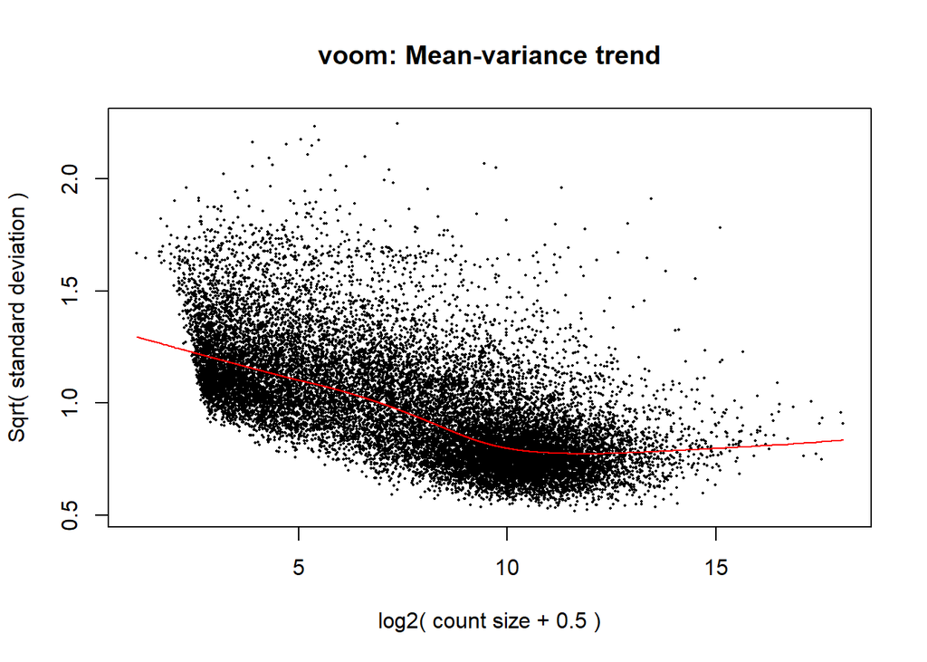

```r
v <- voom(y, design, plot=TRUE) #Produces EList object
```

```r
fit <- lmFit(v, design)
head(coef(fit))
```

```
##                low       high
## TSPAN6    6.916722  7.2849499
## TNMD     -1.475073 -0.4705414
## DPM1      5.434354  5.9115128
## SCYL3     3.753944  3.8124107
## C1orf112  3.244055  3.3665510
## FGR       2.664175  2.2875125
```

```r
contr <- makeContrasts(high - low, levels = colnames(coef(fit)))
contr
```

```
##       Contrasts
## Levels high - low
##   low          -1
##   high          1
```

```r
tmp <- contrasts.fit(fit, contr)

tmp <- eBayes(tmp) #Multiple testing errors => removes false positives
top.table <- topTable(tmp, sort.by = "P", n = Inf) #Extract all DEGs, sort by pvalue
head(top.table, 20)
```

```
##             ID     logFC  AveExpr        t      P.Value    adj.P.Val         B
## 6395      RAC1 0.6166525 8.613494 22.75852 2.196529e-77 4.245231e-73 164.16739
## 125       RALA 0.5309558 6.648964 16.52659 1.639391e-48 1.584225e-44  99.11002
## 4746     ARL4A 0.8156792 4.980149 14.02285 1.870902e-37 1.205297e-33  74.00482
## 2941   TAX1BP1 0.6168272 7.354386 13.72743 3.418561e-36 1.651763e-32  71.27268
## 2978      LSM5 0.6288779 5.581433 13.01001 3.555037e-33 1.374164e-29  64.41621
## 4738      CBX3 0.7023590 7.856605 12.72176 5.529168e-32 1.781037e-28  61.75709
## 6404      HUS1 0.4511743 4.400480 12.36162 1.636670e-30 4.518847e-27  58.30609
## 2897    POLR1F 0.5318752 4.978471 12.34276 1.951757e-30 4.715200e-27  58.19561
## 11252     CYCS 0.7526231 7.795393 12.11825 1.572134e-29 3.376070e-26  56.21330
## 9848      MIOS 0.3859056 5.121818 11.61670 1.547977e-27 2.991774e-24  51.67365
## 11518  DPY19L1 0.5873877 5.637968 11.44687 7.155521e-27 1.257225e-23  50.19325
## 4734   SEPTIN7 0.6076532 6.995409 11.38516 1.244154e-26 2.003813e-23  49.66828
## 6396    KDELR2 0.4389116 8.461089 11.36629 1.473041e-26 2.189958e-23  49.49748
## 3015      RHEB 0.5049540 6.212257 11.34362 1.803885e-26 2.490263e-23  49.29905
## 4745    NT5C3A 0.6011364 5.566448 11.17802 7.873618e-26 1.014489e-22  47.84160
## 15175    UMAD1 0.5547123 3.854164 11.15827 9.378138e-26 1.132820e-22  47.53721
## 16305 MKLN1-AS 0.6468182 2.523351 11.07058 2.034822e-25 2.313354e-22  46.48092
## 2940    HIBADH 0.4870768 6.104232 10.75893 3.103530e-24 3.332329e-21  44.25261
## 11031   KBTBD2 0.3229659 5.820883 10.68727 5.769933e-24 5.869237e-21  43.64230
## 2984      RPA3 0.5496965 4.897967 10.61162 1.107514e-23 1.070246e-20  42.97876
```

```r
#Get the number of DEGs
length(which(top.table$adj.P.Val < 0.05))
```

```
## [1] 8081
```

```r
top.table$Expression = ifelse(top.table$adj.P.Val < 0.05 & abs(top.table$logFC) >= 1,
                            ifelse(top.table$logFC> 1 ,'Up','Down'),
                            'Stable')
table(top.table$Expression)
```

```
##
##   Down Stable     Up
##     38  19263     26
```

### Visual representation

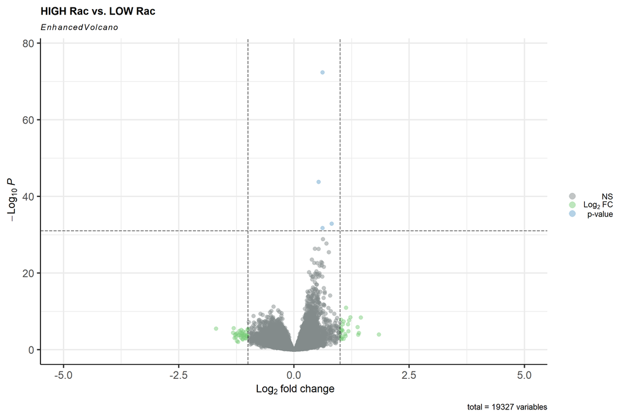

```r
EnhancedVolcano(top.table,
                lab = top.table$ID,
                x= "logFC",
                y= "adj.P.Val",
                title = "HIGH Rac vs. LOW Rac",
                pCutoff = 10e-32,
                FCcutoff = 1,
                pointSize = 3.0,
                labSize = 3.0,
                xlim = c(-5,5),
                # boxedLabels = TRUE,
                col = c("azure4", "palegreen3", "skyblue3", "palevioletred"),
                colAlpha = 0.5,
                legendPosition = 'right')
```